# Лабораторная работа №1

Основы информационной безопасности

Краснова К. Г., НКАбд-03-24

Российский университет дружбы народов, Москва, Россия

17 февраля 2026

# Вводная часть

## Цели и задачи

Целью данной работы является приобретение практических навыков установки операционной системы на виртуальную машину, настройки минимально необходимых для дальнейшей работы сервисов.

## Задание

1. Установка и настройка операционной системы.
2. Найти следующую информацию:
   1. Версия ядра Linux.
   2. Частота процессора.
   3. Модель процессора.
   4. Объем доступной памяти.
   5. Тип обнаруженного гипервизора.
   6. Тип файловой системы корневого раздела.

## Выполнение лабораторной работы

Я выполняю лабораторную работу на домашнем оборудовании, поэтому создаю новую виртуальную машину в VirtualBox, выбираю имя, местоположение и образ ISO, устанавливать будем операционную систему Rocky DVD (рис. 1).

[figure not shown]

создание

## Выполнение лабораторной работы

Выбираю имя пользователя (рис. 2).

[figure not shown]

создание

## Выполнение лабораторной работы

`Размер основной памяти 2048мб, 3 процессора (рис. 3).

[figure not shown]

настройка

## Выполнение лабораторной работы

Выделяю 40 Гб памяти на виртуальном жестком диске (рис. 4).

[figure not shown]

жесткий диск

## Выполнение лабораторной работы

роверяю выставленные настройки (рис. 5).

[figure not shown]

Создание

## Выполнение лабораторной работы

Начинается загрузка ОС. Далее выбираю язык (рис. 6).

[figure not shown]

Выбор языка

## Выполнение лабораторной работы

Меняю часовой пояс, язык раскладки (рис. 7).

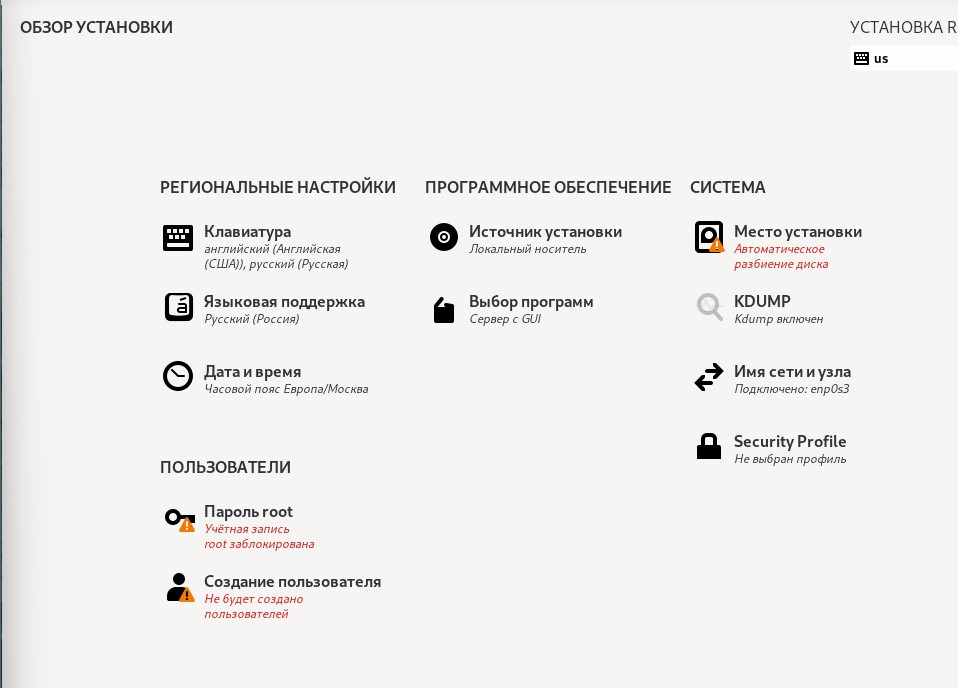

Настройки

## Выполнение лабораторной работы

Установка пароля для администратора(рис. 8).

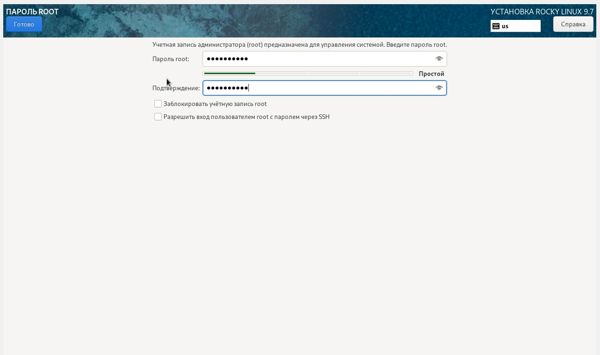

Пароль админ-а

## Выполнение лабораторной работы

Задаю имя пользователя и пароль (рис. 9).

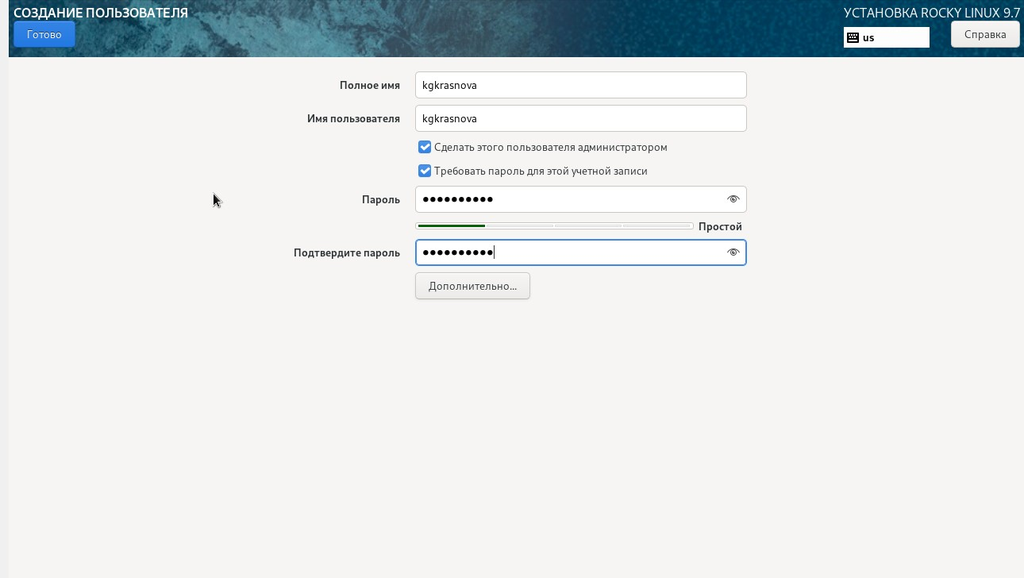

Настройка пользователя

## Выполнение лабораторной работы

Выбираю окружение сервер с GUB и средства разработки в дополнительном программном обеспечении. далее отключаю kdump (рис. 10).

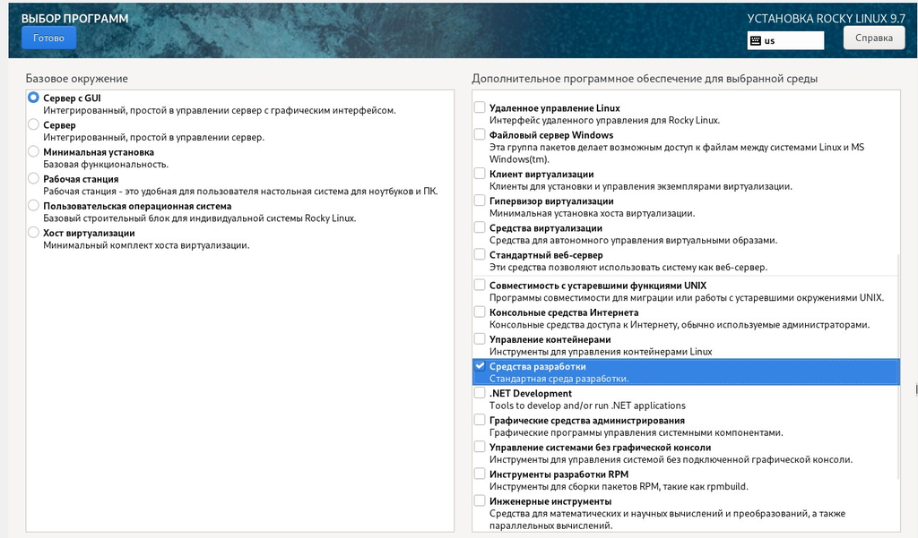

окружение

## Выполнение лабораторной работы

Указываю имя узла в соответствии с соглашением об именовании (рис. 11).

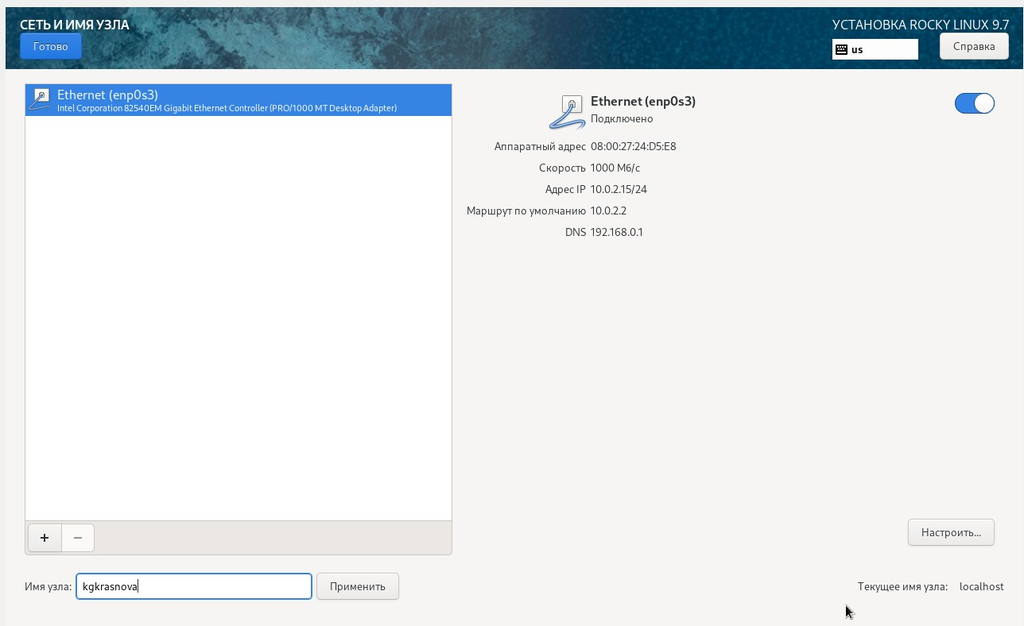

имя узла

## Выполнение лабораторной работы

Начинается установка (рис. 12).

[figure not shown]

Начало установки

## Выполнение лабораторной работы

После установки при запуске операционной системы появляется окно выбора пользователя (рис. 13).

[figure not shown]

Вход в ОС

## Выполнение лабораторной работы

Открываю терминал, в нем прописываю dmesg | less (рис. 14).

[figure not shown]

окно терминала

## Выполнение лабораторной работы

Версия ядра (рис. 15).

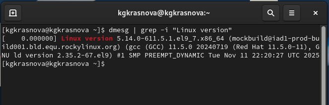

Версия ядра

## Выполнение лабораторной работы

Частота процессора (рис. 16).

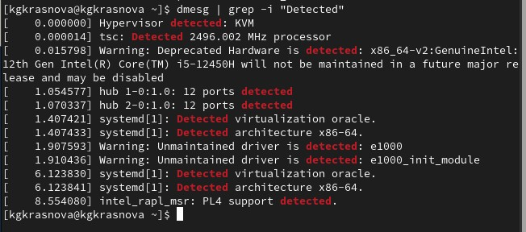

Частота процессора

## Выполнение лабораторной работы

Модель процессора Intel Corе (рис. 17).

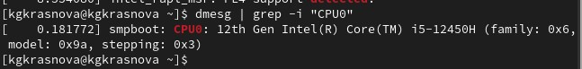

Модель процессора

## Выполнение лабораторной работы

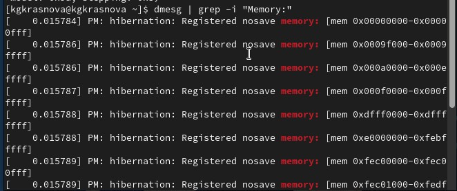

Память

## Выполнение лабораторной работы

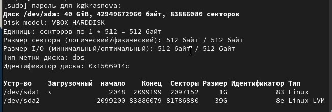

Тип файловой системы

## Выполнение лабораторной работы

Далее показана последовательно монтирования файловых систем (рис. 21).

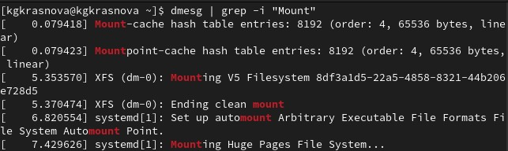

Последовательность монтирования

## Выводы

Я приобрела практические навыки установки операционной системы на виртуальную машину, настройки минимально необходимых для дальнейшей работы сервисов.